# TD : Systèmes à états multiples et Modèles de dégradation

Published

March 6, 2026

# 1 Introduction

Ce notebook présente la résolution détaillée des exercices portant sur les processus de dégradation, les modèles de chocs et les chaînes de Markov appliqués à la fiabilité.

# 2 Exercice 1 : Train d’atterrissage (Dégradation cumulée)

**Énoncé :** Un train d’atterrissage résiste à une pression cumulée de $102\text{ kg/cm}^2$. Les atterrissages d’urgence (chocs) suivent une loi normale $X \sim \mathcal{N}(\mu=50, \sigma=15)$. La fréquence est de $0.004$ atterrissage/an.

### 2.0.1 Question 1 : Modèle de dégradation

Le modèle approprié est un **modèle de chocs cumulés** (processus de Poisson composé). La dégradation totale au temps $t$, $D(t)$, est la somme des chocs subis :

$$D(t) = \sum_{i=1}^{N(t)} X_i$$

Où $N(t)$ est un processus de Poisson de paramètre $\lambda t$ avec $\lambda = 0.004$.

### 2.0.2 Question 2 : Fiabilité à 10 ans

La fiabilité est la probabilité que la dégradation cumulée reste sous le seuil : $R(t) = P(D(t) < 102)$. À $t=10$, l’espérance du nombre de chocs est $E[N(10)] = 0.04$.

- $P(N=0) = e^{-0.04} \approx 0.9608$. La fiabilité est de 1 (pas de choc).
- $P(N=1) = 0.04 e^{-0.04} \approx 0.0384$. On calcule $P(X_1 < 102) = \Phi(\frac{102-50}{15}) \approx 0.9997$.
- $P(N=2) = \frac{0.04^2}{2}e^{-0.04} \approx 0.0008$. Pour deux chocs, la somme suit $\mathcal{N}(100, \sqrt{2}\cdot 15)$, soit $P(\sum X_i < 102) \approx 0.537$.

# 3 Exercice 2 : Serveur informatique (Chocs et CCF)

### 3.0.1 Question 1 : Modèle de chocs et paramètres

- $\nu$ : Taux de périodes de trafic intense ($1 \text{ j}^{-1}$).
- $p$ : Probabilité de défaillance individuelle par choc ($0.3/100 = 0.003$). Le temps avant défaillance par choc suit une loi exponentielle de taux $\lambda_{choc} = \nu \cdot p = \mathbf{0.003 \text{ j}^{-1}}$.

### 3.0.2 Question 3 : Justification du modèle Binomial de CCF

Le modèle de défaillances de cause commune (CCF) binomial est pertinent car les unités sont identiques, partagent le même environnement et subissent le même stress externe (le trafic), avec une probabilité de défaillance supposée indépendante entre unités pour un choc donné.

### 3.0.3 Question 4 : Taux global et Fiabilité

Avec $\lambda_{int} = 1/620 \approx 0.00161 \text{ j}^{-1}$ :

$$\lambda_{total} = \lambda_{int} + \lambda_{choc} = 0.00161 + 0.003 = \mathbf{0.00461 \text{ j}^{-1}}$$

$$R(t) = e^{-0.00461 t}$$

# 4 Exercice 3 : Capteur de température (Modèle Gamma)

### 4.0.1 Question 1 : Modèle à choc cumulé

On utilise un **processus de dégradation Gamma**. La dégradation accumulée $D(t)$ suit une loi Gamma dont les paramètres évoluent avec les surchauffes.

### 4.0.2 Question 2 : Estimation et Simulation

**Voir le code R**

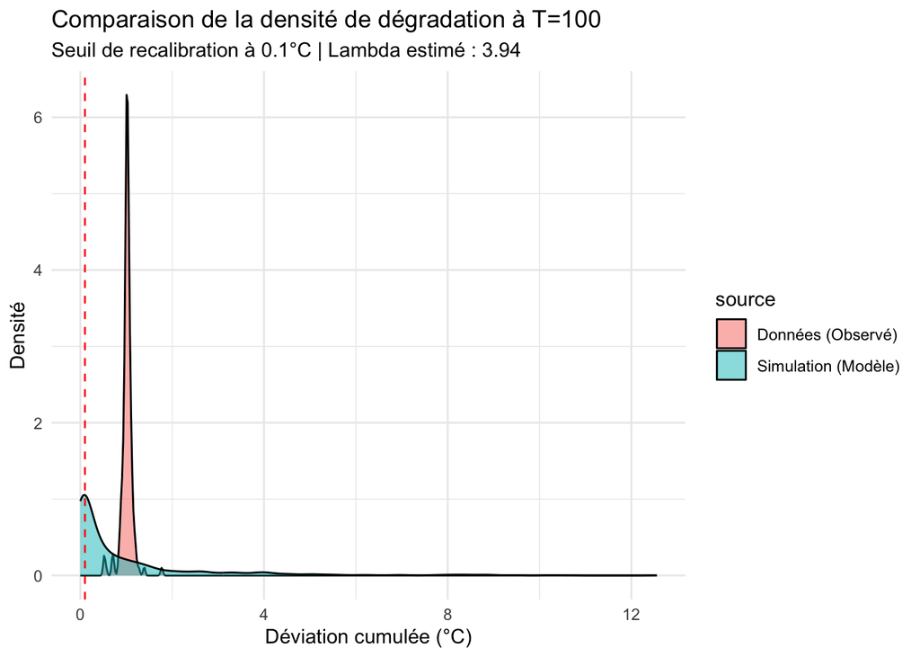

Analyse de la dégradation cumulée : Comparaison Modèle vs Données

```r
sensor_data <- read.csv("../data/td_3/tempsensor.csv")

# 1. Paramètres du choc (incrément de dégradation Gamma)
# Rappel : E[X] = alpha/beta et Var(X) = alpha/beta^2
alpha_gamma <- 8.5e-4
beta_gamma <- 0.33

# 2. Estimation de lambda (fréquence moyenne des surchauffes)
# On calcule le taux par unité de temps pour chaque capteur puis on moyenne
lambda_hat <- mean(sensor_data$nb.overheat / sensor_data$time)

# 3. Simulation du processus de dégradation (Modèle à chocs cumulés)
# On simule 1000 trajectoires sur un horizon T = 100 pour obtenir la distribution
set.seed(123)
sim_degrad <- replicate(1000, {
  n_shocks <- rpois(1, lambda_hat * 100)
  sum(rgamma(n_shocks, shape = alpha_gamma, rate = beta_gamma))
})

# 4. Calcul de la dégradation réelle observée dans les données
# On normalise la dégradation observée à T=100 pour permettre la comparaison
obs_degrad_norm <- (sensor_data$nb.overheat / sensor_data$time) * 100 * (alpha_gamma / beta_gamma)

# 5. Visualisation
library(ggplot2)

df_plot <- data.frame(
  valeur = c(sim_degrad, obs_degrad_norm),
  source = rep(c("Simulation (Modèle)", "Données (Observé)"), c(1000, nrow(sensor_data)))
)

ggplot(df_plot, aes(x = valeur, fill = source)) +
  geom_density(alpha = 0.5) +
  geom_vline(xintercept = 0.1, linetype = "dashed", color = "red") +
  labs(title = "Comparaison de la densité de dégradation à T=100",
       subtitle = paste("Seuil de recalibration à 0.1°C | Lambda estimé :", round(lambda_hat, 2)),
       x = "Déviation cumulée (°C)",
       y = "Densité") +
  theme_minimal()
```

**Voir le code R**

```r
# 6. Analyse statistique
summary(sim_degrad)
```

```
    Min.  1st Qu.   Median     Mean  3rd Qu.     Max.
 0.00000  0.03647  0.28578  0.98740  1.11940 12.55284
```

**Voir le code R**

```r
# Calcul de la probabilité de dépasser le seuil de recalibration (0.1°C) à T=100
prob_recalib <- mean(sim_degrad > 0.1)
cat("Probabilité de devoir recalibrer à T=100 :", round(prob_recalib * 100, 2), "%")
```

```
Probabilité de devoir recalibrer à T=100 : 64.6 %
```

# 5 Exercice 4 : Athlète (Chaîne de Markov Discrète)

### 5.0.1 Question 1 : Modélisation

Les états sont : 1 (Optimal), 2 (Fatigue légère), 3 (Fatigue sévère), 4 (Blessée).

**Voir le code R**

```r
# Matrice de transition
P <- matrix(c(
  0.70, 0.20, 0.08, 0.02,
  0.50, 0.30, 0.15, 0.05,
  0.00, 0.25, 0.65, 0.10,
  0.00, 0.00, 0.20, 0.80
), nrow = 4, ncol = 4, byrow = TRUE)

matrix_power <- function(M, n) {
  res <- M
  if (n > 1) for(i in 2:n) res <- res %*% M
  return(res)
}

# État initial : pleine forme
v0 <- c(1, 0, 0, 0)
v8 <- v0 %*% matrix_power(P, 8)

cat("Probabilité de blessure à 8 semaines :", round(v8[4], 4), "\n")
```

```
Probabilité de blessure à 8 semaines : 0.1657
```

**Voir le code R**

```r
cat("Probabilité de fatigue sévère à 8 semaines :", round(v8[3], 4), "\n")
```

```
Probabilité de fatigue sévère à 8 semaines : 0.2535
```

### 5.0.2 Question 4 : Disponibilité moyenne

La disponibilité stationnaire est la somme des probabilités des états 1 et 2 dans le régime permanent ($\pi P = \pi$).

# 6 Exercice 5 : Radar Standby (Markov Continu)

### 6.0.1 Question 1 : Chaîne de Markov

États : 2 (2 OK), 1 (1 OK, 1 en réparation), 0 (Panne totale).

### 6.0.2 Question 2 : Probabilités stationnaires

Avec $\lambda = 1/35$ et $\mu = 2$, on résout le système d’équilibre :

$$\begin{cases} \pi_2 \lambda = \pi_1 \mu \\ \pi_1 \lambda = \pi_0 \mu \\ \pi_2 + \pi_1 + \pi_0 = 1 \end{cases}$$

**Voir le code R**

```r
lambda <- 1/35
mu <- 2
ratio <- lambda / mu

pi2 <- 1 / (1 + ratio + ratio^2)
pi1 <- ratio * pi2
pi0 <- ratio^2 * pi2

cat("Disponibilité (pi2 + pi1) :", round(pi2 + pi1, 6), "\n")
```

```
Disponibilité (pi2 + pi1) : 0.999799
```

# 7 Exercice 6 : Échangeurs thermiques

### 7.0.1 Question 1 & 2 : Représentation

États : Parfait (P), Partiel (Pa), Sévère (S). **Analyse :** La loi lognormale pour la réparation n’étant pas markovienne (taux non constant), elle ne peut être intégrée directement dans une CTMC classique sans approximation (ex: méthode des phases ou utilisation de l’espérance $1/E[X]$).

### 7.0.2 Question 3 : Dépendance

En cas de dégradation d’un échangeur, le taux de transition de l’autre est multiplié par un facteur d’accélération (1.5 ou 2), traduisant le report de charge.